# Question

A standard ten-sided [die](https://en.wikipedia.org/wiki/Dice) was rolled many times, and the results were organized into the [histogram](https://en.wikipedia.org/wiki/Histogram) shown below.

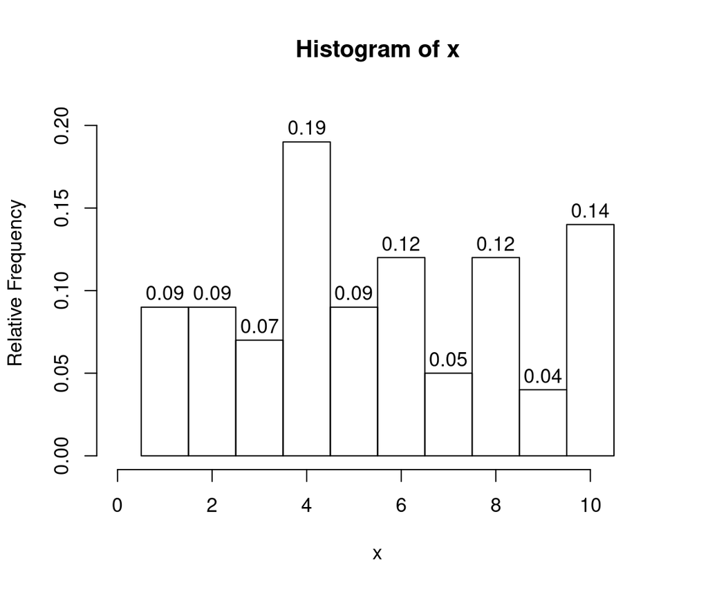

## Answerlist

- Evaluate $\text{prop}[\mathbf{x}<4.5]$.
- Evaluate $\text{prop}[\mathbf{x}>2.5]$.
- Evaluate $\text{prop}[|\mathbf{x}-5|<2.5]$.
- Evaluate $\text{prop}[|\mathbf{x}-6|>3.5]$.
- Evaluate half-integer boundary $b$ such that $\text{prop}[\mathbf{x}<b] = 0.53$.
- Evaluate half-integer boundary $b$ such that $\text{prop}[\mathbf{x}>b] = 0.75$.
- Evaluate half-integer radius $r$ such that $\text{prop}[|\mathbf{x}-4|<r] = 0.35$.
- Evaluate integer radius $r$ such that $\text{prop}[|\mathbf{x}-7.5|>r] = 0.67$.

# Solution

## Answerlist

- The answer is 0.44 because $\text{prop}[\mathbf{x}<4.5]=0.44$.
- The answer is 0.82 because $\text{prop}[\mathbf{x}>2.5]=0.82$.
- The answer is 0.52 because $\text{prop}[|\mathbf{x}-5|<2.5]=0.52$.
- The answer is 0.32 because $\text{prop}[|\mathbf{x}-6|>3.5]=0.32$.
- The answer is 5.5 because $\text{prop}[\mathbf{x}<5.5]=0.53$.
- The answer is 3.5 because $\text{prop}[\mathbf{x}>3.5]=0.75$.
- The answer is 1.5 because $\text{prop}[|\mathbf{x}-4|<1.5]=0.35$.
- The answer is 2 because $\text{prop}[|\mathbf{x}-7.5|>2]=0.67$.

# Meta-information

extype: cloze exclozetype: num|num|num|num|num|num|num|num exsolution: 0.44|0.82|0.52|0.32|5.5|3.5|1.5|2 exname: read_histogram_discrete_prop extol: 0.001 exextra[numwidth]: 999.99